# Twitter Sentiment Analysis using R

Loading packages for accessing Twitter API :

```r
library(twitteR)
library(ROAuth)
library(stringr)
library(dplyr)
```

Using the Keys and Tokens for accessing the twitter API:

Note: An error will show up below as I have used “XXXXX” instead of my actual keys for security reasons. Using the right keys will generate the expected output.

```r
curl.cert <- download.file(url="http://curl.haxx.se/ca/cacert.pem",destfile="cacert.pem")
requestURL <- "https://api.twitter.com/oauth/request_token"
accessURL <- "https://api.twitter.com/oauth/access_token"
authURL <- "https://api.twitter.com/oauth/authorize"
ConsumerKey <- "XXXXX"
ConsumerSecret <- "XXXXX"
AccessToken <-  "XXXXX"
AccessTokenSecret <-    "XXXXX"
setup_twitter_oauth(ConsumerKey, ConsumerSecret, AccessToken, AccessTokenSecret)
```

```
[1] "Using direct authentication"
```

```
Error in check_twitter_oauth() : OAuth authentication error:
This most likely means that you have incorrectly called setup_twitter_oauth()'
```

Importing Tweets about Game Of Thrones from Twitter API :

```r
GOT <- searchTwitter("#GameOfThrones", n = 1000, lang = 'en')
head(GOT)
```

```
[[1]]
[1] "gameofthronesqo: #GameOfThrones You can always say no, Ned. https://t.co/4FJ0oVMQ0g"

[[2]]
[1] "FLWsites: Thanks to Adam W. for suggesting that the Rocketeer be added to our list of movies filmed @FLWsites ! We also added… https://t.co/ujCQ4yQp8s"

[[3]]
[1] "bunyipattack: Happy #letsplaythursday, you guys! We are posting more #reactionvideos from our commentary-riddled #letsplay playth… https://t.co/JHFC7lErgv"

[[4]]
[1] "AriHoopsWagner: Sometimes it's the face you least expect that will tear you down... Perhaps this flip-flop-bro in shorts by a pool… https://t.co/Y2cByhk2BT"

[[5]]
[1] "e1af38f6dbad458: RT @Osman_Marwa1: #MBScomedy \nWhen you get so immersed in #GameOfThrones , #Sercei becomes a hero in your version of the real life series w…"

[[6]]
[1] "manini39aj: RT @NiceQueenCersei: #GameofThrones may not have won at the #GoldenGlobes2018 but @IAMLenaHeadey's enthusiasm and love for Cersei is my #Mo…"
```

Importing libraries for Text Mining :

```r
library(wordcloud)
library(SnowballC)
library(tm)
```

Cleaning the text and obtaining relevant data :

```r
GOT_txt <- sapply(GOT, function(x) x$getText())
GOT_lst <- lapply(GOT, function(x) x$getText())
GOT_txt_Corpus <- Corpus(VectorSource(GOT_txt))
removeURL <- function(x)
  gsub(" ?(f|ht)(tp)(s?)(://)(.*)[.|/](.*)", " ", x)
GOT_txt_Corpus <- tm_map(GOT_txt_Corpus, content_transformer(removeURL))
GOT_txt_Corpus <- tm_map(GOT_txt_Corpus, removePunctuation)
removextra <- function(x)
  gsub("[^[:graph:]]", " ", x)
GOT_txt_Corpus <- tm_map(GOT_txt_Corpus, content_transformer(removextra))
GOT_txt_Corpus <- tm_map(GOT_txt_Corpus, removeWords,  c(stopwords()))
GOT_txt_Corpus <- tm_map(GOT_txt_Corpus, removeWords, c("RT", "the"))
GOT_txt_Corpus <- tm_map(GOT_txt_Corpus, content_transformer(tolower))
GOT_txt_Corpus <- tm_map(GOT_txt_Corpus, removeWords, c("https"))
GOT_x <- TermDocumentMatrix(GOT_txt_Corpus)
GOT_x <- as.matrix(GOT_x)
GOT_x <- sort(rowSums(GOT_x), decreasing = TRUE)
GOT_x <- data.frame(word = names(GOT_x), freq = GOT_x)
```

Visualizing the most used words :

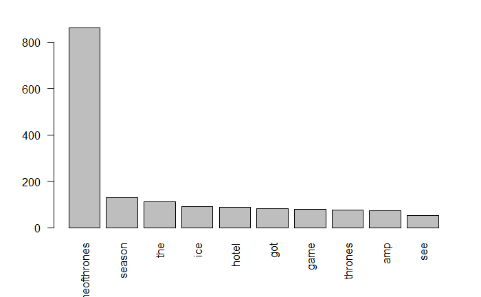

```r
barplot(GOT_x[1:10,]$freq,las =2, names.arg = GOT_x[1:10,]$word)
```

Making a WordCloud out of all the Frequaently used words :

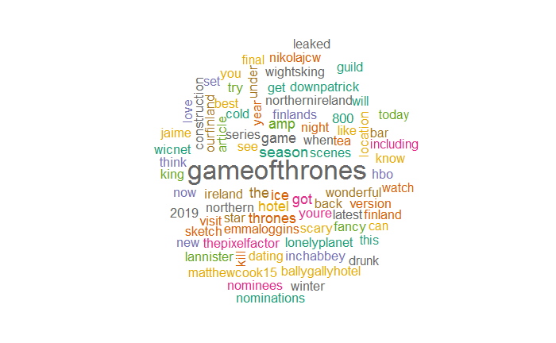

```r
set.seed(1234)
wordcloud(GOT_txt_Corpus, min.freq = 1, max.words = 80, scale = c(2.2,1), colors =brewer.pal(8, "Dark2"), random.color = TRUE, random.order = FALSE)
```

Importing files containg positive and negative words :

```r
pos.words <- read.csv("g:/datasets/positive_words.csv")
neg.words <- read.csv("g:/datasets/negative_words.csv")
pos.words <- scan("g:/datasets/positive_words.csv", what = 'character', comment.char = ";")
```

```
Read 2006 items
```

```r
neg.words <- scan("g:/datasets/negative_words.csv", what = 'character', comment.char = ";")
```

```
Read 4783 items
```

Function for matching the words in the tweets to the positive and negative terms :

```r
score.sentiment = function(tweets, pos.words, neg.words)

{

  require(plyr)
  require(stringr)

  scores = laply(tweets, function(tweet, pos.words, neg.words) {



    tweet = gsub('https://','',tweet) # removes https://
    tweet = gsub('http://','',tweet) # removes http://
    tweet=gsub('[^[:graph:]]', ' ',tweet) ## removes graphic characters
    tweet = gsub('[[:punct:]]', '', tweet) # removes punctuation
    tweet = gsub('[[:cntrl:]]', '', tweet) # removes control characters
    tweet = gsub('\\d+', '', tweet) # removes numbers
    tweet=str_replace_all(tweet,"[^[:graph:]]", " ")

    tweet = tolower(tweet) # makes all letters lowercase

    word.list = str_split(tweet, '\\s+') # splits the tweets by word in a list

    words = unlist(word.list) # turns the list into vector

    pos.matches = match(words, pos.words) ## returns matching
    #values for words from list
    neg.matches = match(words, neg.words)

    pos.matches = !is.na(pos.matches) ## converts matching values to true of false
    neg.matches = !is.na(neg.matches)

    score = sum(pos.matches) - sum(neg.matches) # true and false are
    #treated as 1 and 0 so they can be added

    return(score)

  }, pos.words, neg.words )

  scores.df = data.frame(score=scores, text=tweets)

  return(scores.df)

}
```

Running the above function for tweets analysis :

```r
result <- score.sentiment(GOT_lst, pos.words, neg.words)
```

Histogram of the tweets scores :

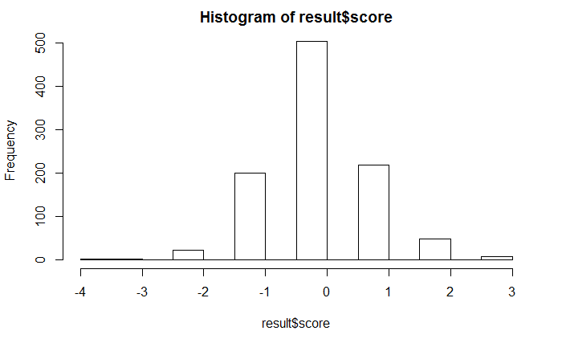

```r
hist(result$score)
```

Conclusion: Thus it is noticed that most of the tweets about Game of Thrones are Neutral tweets. It is also noticed that the there are slightly more postive tweets when compared the the negative tweets.

This program can be easily modified to perform a sentiment analysis on any other term or word.